# Homework 7: Strings + Logical Vectors (Graphical Perception)

Author

MICR 475/575

## Instructions

In this homework you will practice:

- importing a Google Forms CSV export
- working with **strings**
- building and using **logical vectors**
- making data tidy with `pivot_longer()`
- making a simple **box plot**

You will work with a Google Forms CSV export from our in-class graphical perception experiment.

## Setup

```r
library(tidyverse)
csv_path <- "data/handb_ptest.csv"   # <-- update if needed
```

# Q1. Import the data

**Task:** Read the CSV into an object called `raw`, then preview it.

```r
library(readr)
raw <- read_csv("../data/handb_ptest.csv")
View(raw)
```

## Q2. Tidy the data (Method A: pivot_longer first, then rename question type variable)

In the raw Google Forms export, the response columns have long names that include the full question text. Your goal is a tidy data frame with one row per response, and columns:

- `timestamp`
- `chart_type` (values like `T1`, `T2`, …, `T9`)
- `percent` (numeric)

**Task A:** Start from `raw`, `pivot_longer()` everything *except* `timestamp`.

**Task B:** Convert the `percent` column to a number.

**Task C:** Use **string operations** (and at least one **logical vector**) to convert the messy `chart_type` column into clean labels.

> Hint 1: `parse_number(chart_type)` can pull the number out of the string.  
> Hint 2: A logical vector can help you keep only the question numbers you want.

**Task D:** Make a **box plot** of `percent` by `chart_type` (no log transform).

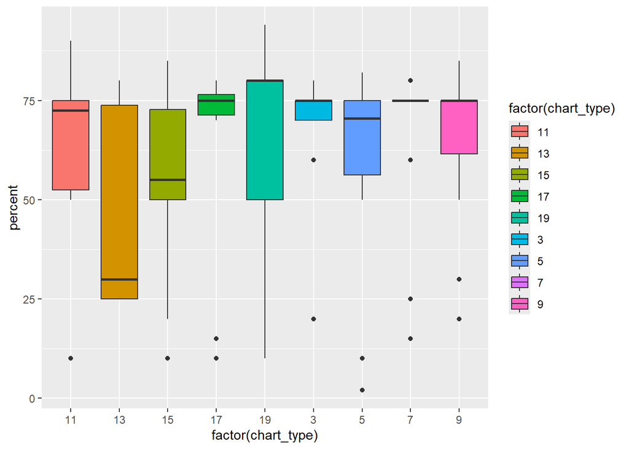

```r
#reorganize columns
mydf <- raw |>
 pivot_longer(
  cols = -Timestamp,
  names_to = c(".value","chart_type"),
  names_pattern = "(.*?)(\\d+)"
)

mydf2 <- mydf |>
   rename(percent = `The smaller is approximately ___% of the larger...`)

mydf3 <- mydf2 |>  mutate(percent = parse_number(as.character(percent)))

mydf4 <- mydf3 |> filter(!is.na(percent))

mydf4 |>
  ggplot(mapping=aes(x= factor(chart_type), y=percent, fill=factor(chart_type)))+
         geom_boxplot()
```

# Q3. Tidy the data (Method B: rename columns first, then pivot_longer)

This method uses the idea that (after `Timestamp`) the remaining columns are the 9 chart types, in order. The following steps provide one way this can be done - if you can get to the right answer using a different method, that’s fine too!

**Task A:** Create a new data frame `df` that keeps `timestamp` plus the 9 response columns.

**Task B:** use the paste0() function to generate a vector of neat column headings ‘T1’, ‘T2’, etc. (keep `timestamp` as-is).

**Task C:** use the function set_names() with your new vector of column names to rename your columns

**Task D:** `pivot_longer()` to make a tidy data frame with `timestamp`, `chart_type`, `percent` (numeric).

**Task E:** Make the same **box plot** of `percent` by `chart_type`.

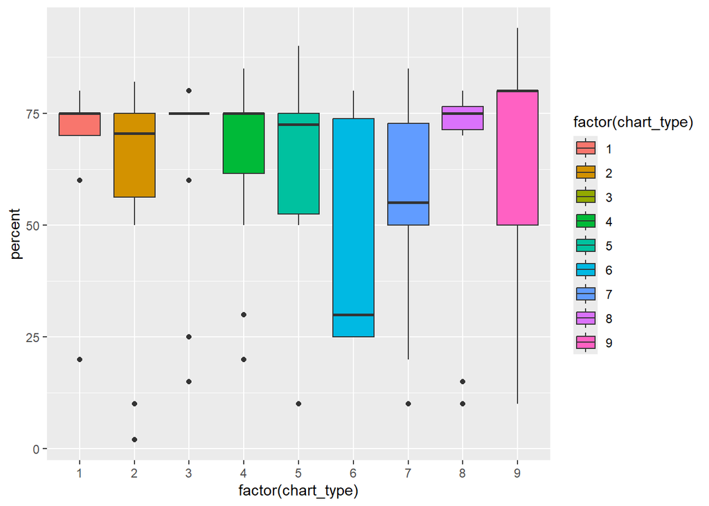

```r
#to not confuse other sections, rename before editing:
q4df <- raw

#task A and B:
old_names <- names(q4df)

qa_cols <- grep("Which item is SMALLER", old_names)
qb_cols <- grep("approximately", old_names)

old_names[qa_cols] <- paste0("QA", 1:length(qa_cols))
old_names[qb_cols] <- paste0("QB", 1:length(qb_cols))

names(q4df) <- old_names

#task D

tidy_q4df <- q4df|>
  pivot_longer(
  cols = -Timestamp,
  names_to = c(".value","chart_type"),
  names_pattern = "(.*?)(\\d+)"
  )
View(tidy_q4df)

final_q4df <- tidy_q4df |>
  rename(percent = QB)
final_q4df <- final_q4df |>
  mutate(percent = parse_number(as.character(percent)))
View(final_q4df)

#plot!

final_q4df |>
  ggplot(mapping=aes(x= factor(chart_type), y=percent, fill=factor(chart_type)))+
         geom_boxplot()
```

# Q4. Do the two methods agree?

**Task A:** Check that the boxplots from Q2 and Q3 are the same. It’s ok if they aren’t - just please comment on why they disagree

**Task B:** In 3–6 sentences, comment on what the box plots show. Does it give the same gist that we would expect from Heer and Bostock’s results? If not, why not?

These do show the same information but Q3 is much easier to identify the results. I believe the biggest reason for thisis that the order of solving the second method (Q3) made it easier to assign the correct chart types to question numbers, and then keep them in order. There are edits that could be made to Q2, but the fact that Q3 was able to reach the best format the easiest shows that this is the correct method, at least for me personally. These show that different chart types lead to a broad range of accuracy levels in the reader actually properly understanding the data presented!